# Water Potability Code

The Boop Beepers

Author

Malva de Boor, Albert Song, Henry Shavel, Tyler McLaughlin

Published

February 27, 2023

Abstract

*This file contains the code for the project on Water Potability, as part of the STAT303-2 course in Winter 2023*.

```python
import pandas as pd
import numpy as np
import statsmodels.formula.api as smf
import seaborn as sns
import matplotlib.pyplot as plt
import statsmodels.formula.api as sm
import itertools
water = pd.read_csv('drinking_water_potability.csv')
water.head()
```

|  | ph | Hardness | Solids | Chloramines | Sulfate | Conductivity | Organic_carbon | Trihalomethanes | Turbidity | Potability |
| --- | --- | --- | --- | --- | --- | --- | --- | --- | --- | --- |
| 0 | NaN | 204.890456 | 20791.31898 | 7.300212 | 368.516441 | 564.308654 | 10.379783 | 86.990970 | 2.963135 | 0 |
| 1 | 3.716080 | 129.422921 | 18630.05786 | 6.635246 | NaN | 592.885359 | 15.180013 | 56.329076 | 4.500656 | 0 |
| 2 | 8.099124 | 224.236259 | 19909.54173 | 9.275884 | NaN | 418.606213 | 16.868637 | 66.420093 | 3.055934 | 0 |
| 3 | 8.316766 | 214.373394 | 22018.41744 | 8.059332 | 356.886136 | 363.266516 | 18.436525 | 100.341674 | 4.628771 | 0 |
| 4 | 9.092223 | 181.101509 | 17978.98634 | 6.546600 | 310.135738 | 398.410813 | 11.558279 | 31.997993 | 4.075075 | 0 |

## 1 Data quality check / cleaning / preparation

### 1.1 Data quality check

*By Henry Shavel*

The code below visualizes the distribution of all the variables in the dataset, and their association with the response.

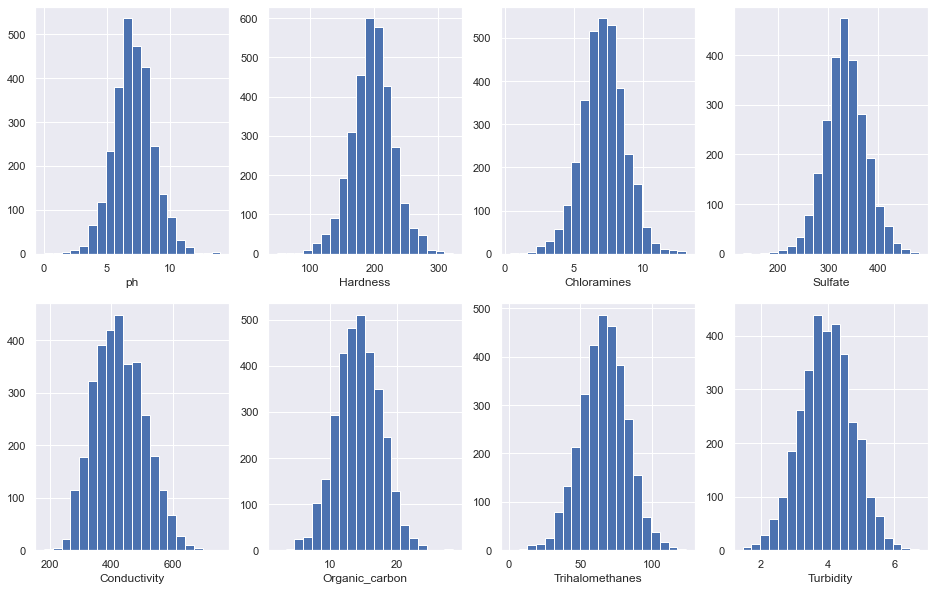

```python
#...Distribution of continuous variables...#
fig, axes = plt.subplots(2,4,figsize=(16,10))
plt.subplots_adjust(wspace=0.2)
axes[0,0].hist(x ="ph", data = water, bins = 20)
axes[0,0].set_xlabel("ph",fontsize = 12)
axes[0,1].hist(x = "Hardness", data = water, bins = 20)
axes[0,1].set_xlabel("Hardness",fontsize = 12)
axes[0,2].hist(x = "Chloramines", data = water, bins = 20)
axes[0,2].set_xlabel("Chloramines",fontsize = 12)
axes[0,3].hist(x = "Sulfate", data = water, bins = 20)
axes[0,3].set_xlabel("Sulfate",fontsize = 12)
axes[1,0].hist(x = "Conductivity", data = water, bins = 20)
axes[1,0].set_xlabel("Conductivity",fontsize = 12)
axes[1,1].hist(x = "Organic_carbon", data = water, bins = 20)
axes[1,1].set_xlabel("Organic_carbon",fontsize = 12)
axes[1,2].hist(x = "Trihalomethanes", data = water, bins = 20)
axes[1,2].set_xlabel("Trihalomethanes",fontsize = 12)
axes[1,3].hist(x = "Turbidity", data = water, bins = 20)
axes[1,3].set_xlabel("Turbidity",fontsize = 12)
```

```
 [Text(0, 0, '0'), Text(1, 0, '1')])
```

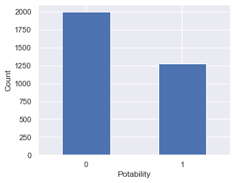

```python
#...Distribution of categorical variables...#
#sns.barplot(x ="Potability", data = water)
ax = water['Potability'].value_counts().plot.bar(ylabel = 'Count', xlabel = 'Potability')
plt.xticks([0,1], [0,1], rotation='horizontal')
```

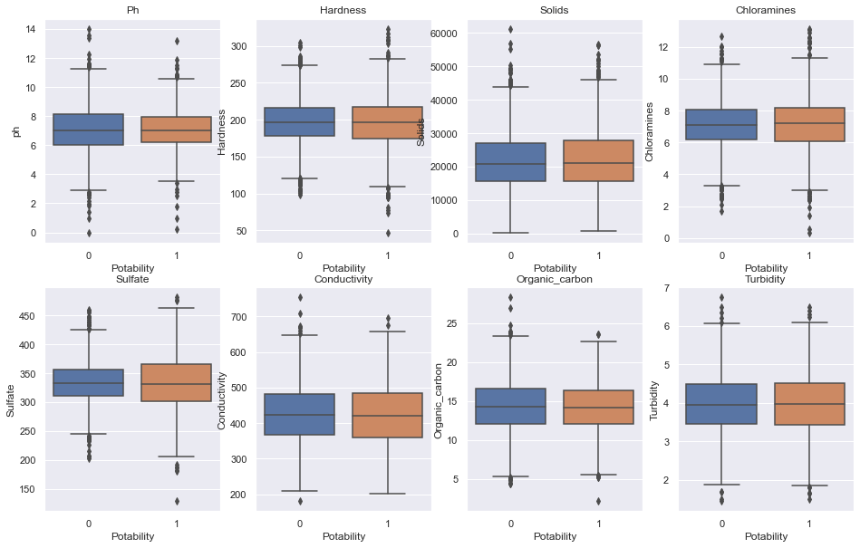

```python
#...Association of the response with the predictors...#
fig, axes = plt.subplots(2,4,figsize=(16,10))
plt.subplots_adjust(wspace=0.2)
sns.boxplot(ax = axes[0,0], x = "Potability", y="ph", data = water)
axes[0,0].set_title("Ph")
sns.boxplot(ax = axes[0,1], x = "Potability", y="Hardness", data = water)
axes[0,1].set_title("Hardness")
sns.boxplot(ax = axes[0,2], x = "Potability", y="Solids", data = water)
axes[0,2].set_title("Solids")
sns.boxplot(ax = axes[0,3], x = "Potability", y="Chloramines", data = water)
axes[0,3].set_title("Chloramines")
sns.boxplot(ax = axes[1,0], x = "Potability", y="Sulfate", data = water)
axes[1,0].set_title("Sulfate")
sns.boxplot(ax = axes[1,1], x = "Potability", y="Conductivity", data = water)
axes[1,1].set_title("Conductivity")
sns.boxplot(ax = axes[1,2], x = "Potability", y="Organic_carbon", data = water)
axes[1,2].set_title("Organic_carbon")
sns.boxplot(ax = axes[1,3], x = "Potability", y="Turbidity", data = water)
axes[1,3].set_title("Turbidity")
```

### 1.2 Data cleaning

*By Henry Shavel*

The code below implements the above cleaning.

```python
#dropping all rows with missing values from the data frame.#
water = water.dropna()
```

### 1.3 Data preparation

*By Malva de Boor*

In order to prepare the data for the development of the model, we randomly split the data into a training dataset and a test dataset. The training dataset was 80% of the original dataset and the test dataset was the remaining 20%. We also calculated the accuracy of the null model by determining the number of ones and zeros in the dataset.

```python
#Shuffling the dataset for random selection of train and test data
np.random.seed(2)
#80% to be training
train = water.sample(round(water.shape[0]*.8))
#drop the train data from the test df
test = water.drop(train.index)
```

```python
#Determining accuracy of naive model
water.Potability.value_counts(1)
```

```
0    0.596718
1    0.403282
Name: Potability, dtype: float64
```

## 2 Exploratory data analysis

*By Tyler McLaughlin*

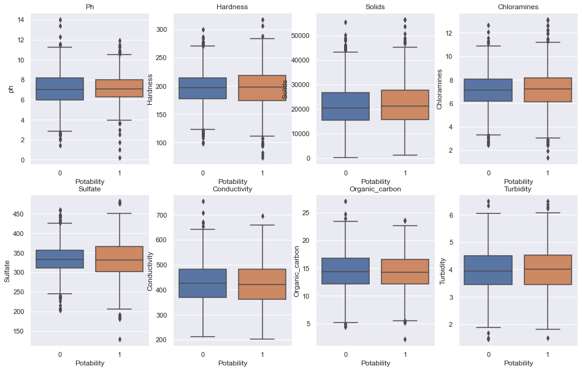

```python
#creating subplots of target variable versus predictor
fig, axes = plt.subplots(2,4,figsize=(16,10))
plt.subplots_adjust(wspace=0.2)
sns.boxplot(ax = axes[0,0], x = "Potability", y="ph", data = water)
axes[0,0].set_title("Ph")
sns.boxplot(ax = axes[0,1], x = "Potability", y="Hardness", data = water)
axes[0,1].set_title("Hardness")
sns.boxplot(ax = axes[0,2], x = "Potability", y="Solids", data = water)
axes[0,2].set_title("Solids")
sns.boxplot(ax = axes[0,3], x = "Potability", y="Chloramines", data = water)
axes[0,3].set_title("Chloramines")
sns.boxplot(ax = axes[1,0], x = "Potability", y="Sulfate", data = water)
axes[1,0].set_title("Sulfate")
sns.boxplot(ax = axes[1,1], x = "Potability", y="Conductivity", data = water)
axes[1,1].set_title("Conductivity")
sns.boxplot(ax = axes[1,2], x = "Potability", y="Organic_carbon", data = water)
axes[1,2].set_title("Organic_carbon")
sns.boxplot(ax = axes[1,3], x = "Potability", y="Turbidity", data = water)
axes[1,3].set_title("Turbidity")
```

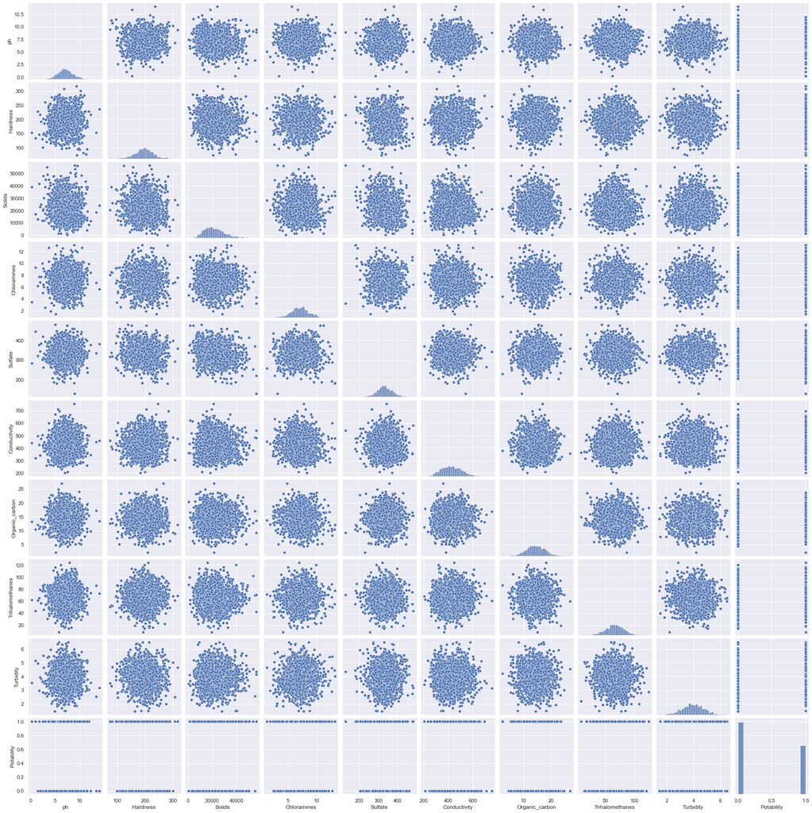

```python
#Examining relationships between the explanatory variables (Scatterplot matrix)
sns.pairplot(water)
```

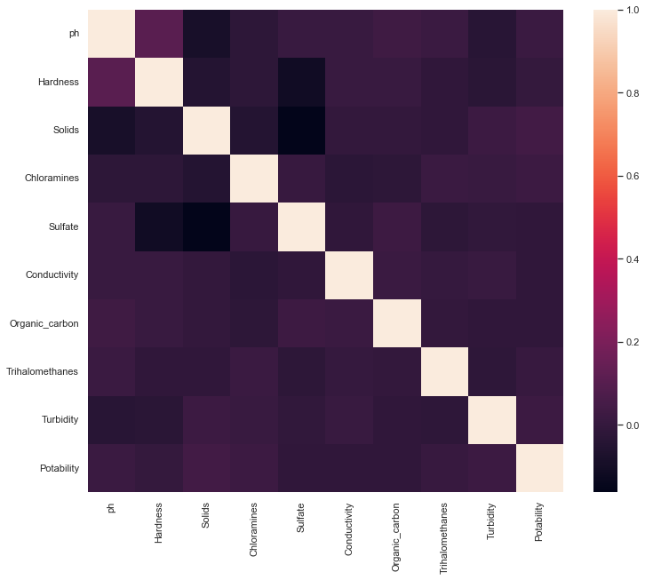

```python
#Examining relationships between the explanatory variables (Correlation heatmap)
sns.set(rc={'figure.figsize':(12,10)})
sns.heatmap(water.corr())
```

## 3 Developing the model

### 3.1 Functions for Confusion Matrix, Classification Accuracy, Plotting Subset Selection

*By Malva de Boor*

```python
def confusion_matrix_test(data,actual_values,model,cutoff=0.5):
    sns.set(rc={'figure.figsize':(5,4)})
    #Predicting the values using the Logit model
    pred_values = model.predict(data)
    #Specifying the bins for the predicted probabilities
    bins=np.array([0,cutoff,1])
    #Creating the confusion matrix
    cm = np.histogram2d(actual_values, pred_values, bins=bins)[0]
    cm_df = pd.DataFrame(cm)
    cm_df.columns = ['Predicted 0','Predicted 1']
    cm_df = cm_df.rename(index={0: 'Actual 0',1:'Actual 1'})
    accuracy = (cm[0,0]+cm[1,1])/cm.sum()
    #Displaying the confusion matrix
    sns.heatmap(cm_df, annot=True, cmap='Blues', fmt='g')
    plt.ylabel("Actual Values")
    plt.xlabel("Predicted Values")
    print("Classification accuracy = {:.1%}".format(accuracy))
    return cm

#This function is the same as the one above except it returns the accuracy instead
#of the confusion matrix for easier use in variable selection later
def accuracytest(data,actual_values,model,cutoff=0.5):
    pred_values = model.predict(data)
    bins=np.array([0,cutoff,1])
    cm = np.histogram2d(actual_values, pred_values, bins=bins)[0]
    accuracy = (cm[0,0]+cm[1,1])/cm.sum()
    return accuracy

def best_sub_plots():
    plt.figure(figsize=(20,10))
    plt.rcParams.update({'font.size': 18, 'lines.markersize': 10})

    #Plotting selection based on Accuracy
    plt.subplot(2, 2, 1)
    accuracy = models_best.apply(lambda row: accuracytest(test,test.Potability,row[1],cutoff=0.5), axis=1)
    plt.plot(models_best["Accuracy"])
    plt.plot(1+accuracy.argmax(), accuracy.max(), "or") #plotting red dot on maximum
    plt.xlabel('# Predictors')
    plt.ylabel('Accuracy')

    #Plotting selection based on AIC
    plt.subplot(2, 2, 2)
    aic = models_best.apply(lambda row: row[1].aic, axis=1)
    plt.plot(aic)
    plt.plot(1+aic.argmin(), aic.min(), "or") #plotting red dot on minimum
    plt.xlabel('# Predictors')
    plt.ylabel('AIC')

    #Plotting selection based on BIC
    plt.subplot(2, 2, 3)
    bic = models_best.apply(lambda row: row[1].bic, axis=1)
    plt.plot(bic)
    plt.plot(1+bic.argmin(), bic.min(), "or") #plotting red dot on minimum
    plt.xlabel('# Predictors')
    plt.ylabel('BIC')

def processSubset(predictor_subset):
    #Fit model on feature_set and calculate classification accuracy
    #Model including all predictors in predictor_subset
    model = sm.logit('Potability~' + '+'.join(predictor_subset),data = train).fit(disp=0)
    accuracy = accuracytest(test,test.Potability,model,cutoff=0.5)
    return {"model":model, "Accuracy":accuracy}
```

### 3.2 Baseline Model

*By Malva de Boor*

```
Classification accuracy = 59.8%
FPR = 0.17%
```

```
0.5977125808055693
```

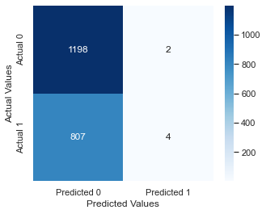

```python
#Making a logistic model with all the predictors
logit_model = sm.logit(formula = 'Potability~ph+Hardness+Solids+Chloramines+Sulfate+\
                Organic_carbon+Conductivity+Turbidity+Trihalomethanes', data = water).fit(disp=0)
logit_model.summary()
#Displaying the confusion matrix and the FPR of the model
cm = confusion_matrix_test(water,water.Potability,logit_model,.5)
fpr = cm[0,1]/(cm[0,1]+cm[0,0])
print('FPR = {:.2%}'.format(fpr))
(cm[0,0]+cm[1,1])/(cm[0,1]+cm[0,0]+cm[1,1]+cm[1,0])
```

### 3.3 Ridge Regression

*By Albert Song*

```python
from sklearn.preprocessing import StandardScaler
#Defines dataframes for ridge regression

#y = train.filter(items=['Potability'])
y = train.Potability
X = train.drop('Potability', axis=1)

#testY = test.filter(items=['Potability'])
testY = test.Potability
testX = test.drop('Potability', axis=1)

scaler = StandardScaler()

#The scaler object will contain the mean and variance of each column (predictor) of X.
#These values will be useful to scale test data based on the same mean and variance as obtained on train data
scaler.fit(X)

#Using the scaler object (or the values of mean and variance stored in it) to standardize X (or train data)
Xstd = scaler.transform(X)
XTeststd = scaler.transform(testX)
```

```python
from sklearn.model_selection import cross_val_score
from sklearn.model_selection import RepeatedKFold
from sklearn.linear_model import RidgeClassifier
from sklearn.model_selection import GridSearchCV

#Creates ridge classifier object
model = RidgeClassifier()
#Defines cv test, with 10 splits and 3 repeated tries
cv = RepeatedKFold(n_splits=10, n_repeats=3, random_state=1)
#creates grid of alphas to test ridge on
grid = dict()
grid['alpha'] = np.arange(0, 1, 0.01)
#defines the search for the best model based on mae
search = GridSearchCV(model, grid, scoring='neg_mean_absolute_error', cv=cv, n_jobs=-1)
# perform the search
results = search.fit(Xstd, y)
print('Best MAE is %.3f' % results.best_score_)
print('Best alpha param is %s' % results.best_params_)
```

```
Best MAE is -0.407
Best alpha param is {'alpha': 0.0}
```

```python
ridgeModel = RidgeClassifier(alpha = 0)
predictedY = ridgeModel.fit(Xstd, y).predict(XTeststd)
#Determining false/true positives/negatives for precision and accuracy
tp = 0
tn = 0
fp = 0
fn = 0
for ii in range(0, len(predictedY)):
    if predictedY[ii] == 0:
        if testY.iloc[ii] == 0:
            tn += 1
        else:
            fn +=1
    else:
        if testY.iloc[ii] == 1:
            tp += 1
        else:
            fp += 1

#calculating precision and accuracy
print(str((tp+tn) / len(predictedY)) + ' Accuracy')
print(str(fp / (tp + fp)) + ' Precision')
```

```
0.6243781094527363 Accuracy
0.3333333333333333 Precision
```

### 3.4 Forward Selection

*By Malva de Boor*

```python
#Eliminating dataframe reassignment errors
pd.set_option('mode.chained_assignment', None)
from warnings import simplefilter
simplefilter(action="ignore", category=pd.errors.PerformanceWarning)
```

```python
#Creating a dataframe with all the predictors
X = train.loc[:, train.columns!='Potability']
train2 = train.copy()
test2 = test.copy()
#backup X
X_backup = train.loc[:, train.columns!='Potability']
#Including 2-factor interactions of predictors in train and 'X'.
for combo in itertools.combinations(X_backup.columns, 2):
    train['_'.join(combo)] = train[combo[0]]*train[combo[1]]
    test['_'.join(combo)] = test[combo[0]]*test[combo[1]]
    X.loc[:,'_'.join(combo)] = train.loc[:,'_'.join(combo)]
```

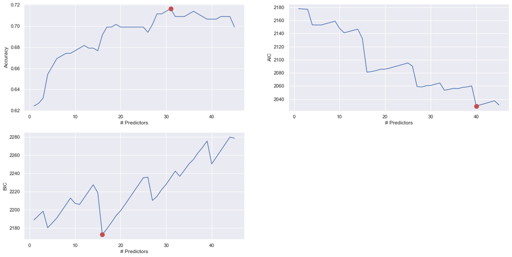

```python
#Function to find the best predictor out of p-k predictors and add it to the model containing the k predictors
def forward(predictors):

    # Pull out predictors that still haven't been added to the model
    remaining_predictors = [p for p in X.columns if p not in predictors]
    results = []

    #making a model for every possible new predictor
    for p in remaining_predictors:
        results.append(processSubset(predictors+[p]))

    models = pd.DataFrame(results)

    #Choose the model with the highest Accuracy
    best_model = models.loc[models['Accuracy'].argmax()]

    #Return the best model
    return best_model

def forward_selection():
    models_best = pd.DataFrame(columns=["Accuracy", "model"])

    predictors = []

    for i in range(1,len(X.columns)+1):
        models_best.loc[i] = forward(predictors) #calling forward selection
        #setting predictors in model equal to the ones used in the current iteration in
        #preparation for the next iteration
        predictors = list(models_best.loc[i]["model"].params.index[1:])
    return models_best

models_best = forward_selection()
best_sub_plots() #plot the results
```

```python
#Finding the number of predictors that maximized Accuracy and minimized AIC and BIC
print("Accuracy:",models_best.Accuracy.loc[models_best.Accuracy == models_best.Accuracy.max()].index[0])
print("AIC:",models_best.apply(lambda row: row[1].aic, axis=1).idxmin())
print("BIC:",models_best.apply(lambda row: row[1].bic, axis=1).idxmin())
```

```
Accuracy: 31
AIC: 40
BIC: 16
```

```
Classification accuracy = 71.6%
Recall: 73.8% FPR: 8.4%
```

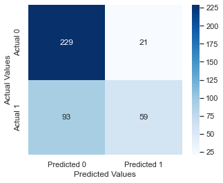

```python
#Best model based on classification accuracy
cm = confusion_matrix_test(test,test.Potability,models_best.loc[31,'model'],cutoff=0.5)
recall = cm[1,1]/(cm[1,1]+cm[0,1])
fpr = cm[0,1]/(cm[0,1]+cm[0,0])
print('Recall: {:.1%}'.format(recall),'FPR: {:.1%}'.format(fpr))
```

```
Classification accuracy = 70.6%
Recall: 71.2% FPR: 9.2%
```

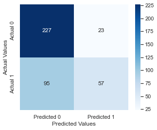

```python
#Best model based on AIC
cm = confusion_matrix_test(test,test.Potability,models_best.loc[40,'model'],cutoff=0.5)
recall = cm[1,1]/(cm[1,1]+cm[0,1])
fpr = cm[0,1]/(cm[0,1]+cm[0,0])
print('Recall: {:.1%}'.format(recall),'FPR: {:.1%}'.format(fpr))
```

```
Classification accuracy = 69.2%
Recall: 72.6% FPR: 6.8%
```

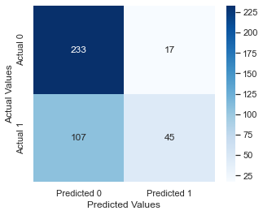

```python
#Best model based on BIC
cm = confusion_matrix_test(test,test.Potability,models_best.loc[16,'model'],cutoff=0.5)
recall = cm[1,1]/(cm[1,1]+cm[0,1])
fpr = cm[0,1]/(cm[0,1]+cm[0,0])
print('Recall: {:.1%}'.format(recall),'FPR: {:.1%}'.format(fpr))
```

### 3.5 Backward Selection

*By Henry Shavel*

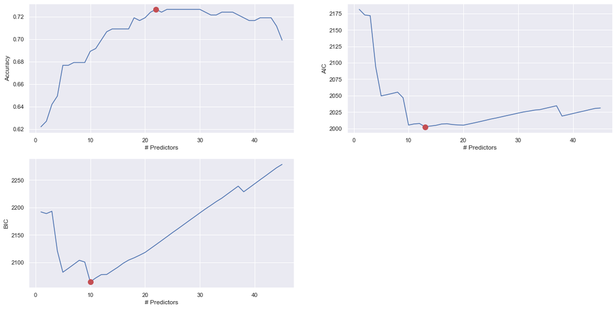

```python
#backward
def backward(predictors):

    tic = time.time()

    results = []

    for combo in itertools.combinations(predictors, len(predictors)-1):
        results.append(processSubset(combo))

    # Wrap everything up in a nice dataframe
    models = pd.DataFrame(results)

    # Choose the model with the highest classification accuracy
    best_model = models.loc[models['Accuracy'].argmax()]
    # Return the best model, along with some other useful information about the model
    return best_model
def backward_selection():
    #Creating a list of the best models
    models_best = pd.DataFrame(columns=["Accuracy", "model"], index = range(1,len(X.columns)))

    #Creating a list of possible predictors
    predictors = X.columns
    #creating model with predictors
    models_best.loc[len(predictors)] = processSubset(predictors)
    #running backward function
    while(len(predictors) > 1):
        models_best.loc[len(predictors)-1] = backward(predictors)
        predictors = models_best.loc[len(predictors)-1]["model"].params.index[1:]
    #returning list of best models
    return models_best
#caling the function
models_best = backward_selection()
best_sub_plots()
```

```python
#Finding the number of predictors that maximized Accuracy and minimized AIC and BIC
print("Accuracy:",models_best.Accuracy.loc[models_best.Accuracy == models_best.Accuracy.max()].index[0])
print("AIC:",models_best.apply(lambda row: row[1].aic, axis=1).idxmin())
print("BIC:",models_best.apply(lambda row: row[1].bic, axis=1).idxmin())
```

```
Accuracy: 22
AIC: 13
BIC: 10
```

```
Classification accuracy = 72.6%
Recall: 76.2% FPR: 7.6%
Classification accuracy = 70.6%
Recall: 71.2% FPR: 9.2%
Classification accuracy = 68.9%
Recall: 68.0% FPR: 9.6%
```

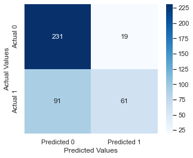

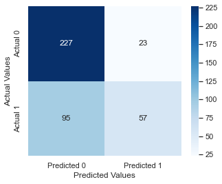

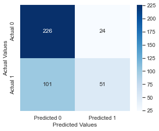

```python
#Best model based on classification accuracy
cm = confusion_matrix_test(test,test.Potability,models_best.loc[22,'model'],cutoff=0.5)
recall = cm[1,1]/(cm[1,1]+cm[0,1])
fpr = cm[0,1]/(cm[0,1]+cm[0,0])
print('Recall: {:.1%}'.format(recall),'FPR: {:.1%}'.format(fpr))
plt.figure()
#Best model based on AIC
cm = confusion_matrix_test(test,test.Potability,models_best.loc[13,'model'],cutoff=0.5)
recall = cm[1,1]/(cm[1,1]+cm[0,1])
fpr = cm[0,1]/(cm[0,1]+cm[0,0])
print('Recall: {:.1%}'.format(recall),'FPR: {:.1%}'.format(fpr))
plt.figure()
#Best model based on classification accuracy
cm = confusion_matrix_test(test,test.Potability,models_best.loc[10,'model'],cutoff=0.5)
recall = cm[1,1]/(cm[1,1]+cm[0,1])
fpr = cm[0,1]/(cm[0,1]+cm[0,0])
print('Recall: {:.1%}'.format(recall),'FPR: {:.1%}'.format(fpr))
```

```python
#choosing the model with the highest classification accuracy from backward selection
best_in_model = models_best.loc[22,'model']
#creating an arracy for accuracies
accuracy = np.array([])
#running a for loop that tests all possible cubic transformations on the best model determined from backward selection
for i in X_backup.columns:
    model = sm.logit("Potability~" + "+".join(best_in_model.params.index[1:]) + "+I(" + i + "**2)+I(" + i + "**3)", data = train).fit(disp=0)
    accuracy = np.append(accuracy,accuracytest(test,test.Potability,model,cutoff=0.5))
print(round(max(accuracy)*100,1),'%')
```

```
72.6 %
```

### 3.6 Code fitting the final model

```python
final_model = sm.logit("Potability~" + "+".join(best_in_model.params.index[1:]), data = train).fit(disp=0)
final_model.summary()
```

Logit Regression Results

| Dep. Variable: | Potability | No. Observations: | 1609 |
| --- | --- | --- | --- |
| Model: | Logit | Df Residuals: | 1586 |
| Method: | MLE | Df Model: | 22 |
| Date: | Sun, 12 Mar 2023 | Pseudo R-squ.: | 0.09884 |
| Time: | 23:17:04 | Log-Likelihood: | -981.19 |
| converged: | True | LL-Null: | -1088.8 |
| Covariance Type: | nonrobust | LLR p-value: | 1.153e-33 |

|  | coef | std err | z | P>\|z\| | [0.025 | 0.975] |
| --- | --- | --- | --- | --- | --- | --- |
| Intercept | -23.9065 | 3.939 | -6.069 | 0.000 | -31.627 | -16.186 |
| ph | 2.8165 | 0.500 | 5.630 | 0.000 | 1.836 | 3.797 |
| Solids | 0.0004 | 9.38e-05 | 4.766 | 0.000 | 0.000 | 0.001 |
| Chloramines | -0.4270 | 0.281 | -1.521 | 0.128 | -0.977 | 0.123 |
| Sulfate | 0.0842 | 0.010 | 8.115 | 0.000 | 0.064 | 0.105 |
| Conductivity | -0.0138 | 0.006 | -2.143 | 0.032 | -0.027 | -0.001 |
| Organic_carbon | -0.0950 | 0.098 | -0.974 | 0.330 | -0.286 | 0.096 |
| ph_Hardness | -0.0022 | 0.001 | -2.258 | 0.024 | -0.004 | -0.000 |
| ph_Chloramines | 0.1448 | 0.025 | 5.714 | 0.000 | 0.095 | 0.195 |
| ph_Sulfate | -0.0096 | 0.001 | -8.918 | 0.000 | -0.012 | -0.008 |
| ph_Conductivity | -0.0004 | 0.001 | -0.844 | 0.399 | -0.001 | 0.001 |
| Hardness_Solids | -2.95e-07 | 1.93e-07 | -1.529 | 0.126 | -6.73e-07 | 8.32e-08 |
| Hardness_Chloramines | -0.0016 | 0.001 | -1.579 | 0.114 | -0.004 | 0.000 |
| Hardness_Sulfate | 5.571e-05 | 2.88e-05 | 1.932 | 0.053 | -8.09e-07 | 0.000 |
| Hardness_Conductivity | 3.777e-05 | 1.92e-05 | 1.970 | 0.049 | 1.84e-07 | 7.54e-05 |
| Solids_Chloramines | -1.209e-05 | 4.48e-06 | -2.700 | 0.007 | -2.09e-05 | -3.31e-06 |
| Solids_Sulfate | -9.902e-07 | 1.73e-07 | -5.730 | 0.000 | -1.33e-06 | -6.51e-07 |
| Solids_Conductivity | 4.434e-08 | 8.16e-08 | 0.543 | 0.587 | -1.16e-07 | 2.04e-07 |
| Solids_Organic_carbon | -9.351e-07 | 1.92e-06 | -0.486 | 0.627 | -4.7e-06 | 2.83e-06 |
| Solids_Trihalomethanes | 4.074e-07 | 3.98e-07 | 1.023 | 0.306 | -3.73e-07 | 1.19e-06 |
| Sulfate_Trihalomethanes | -0.0001 | 5.22e-05 | -2.158 | 0.031 | -0.000 | -1.03e-05 |
| Conductivity_Organic_carbon | 0.0002 | 0.000 | 1.199 | 0.230 | -0.000 | 0.001 |
| Conductivity_Trihalomethanes | 6.752e-05 | 3.84e-05 | 1.759 | 0.079 | -7.72e-06 | 0.000 |

```
Classification accuracy = 72.6%
Recall: 76.2% FPR: 7.6%
```

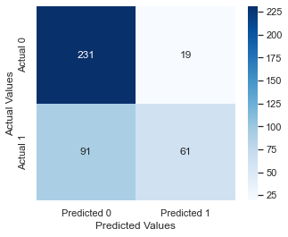

```python
cm = confusion_matrix_test(test,test.Potability,final_model,cutoff=0.5)
recall = cm[1,1]/(cm[1,1]+cm[0,1])
fpr = cm[0,1]/(cm[0,1]+cm[0,0])
print('Recall: {:.1%}'.format(recall),'FPR: {:.1%}'.format(fpr))
```